# Data Visualization

# 7. Visualization of Distributions

Another important visualization that you would like to look at will be distribution/histogram of your variable. Remember that histogram is nothing but a special case of bar charts for continuous numeric variables where x axis is made up bins depending on values of the data mapped to x aesthetic and y axis still represent counts.

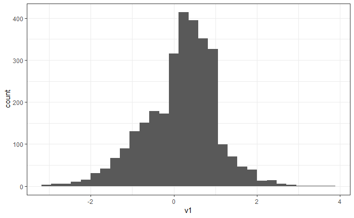

Lets visualize **Normal** and **Uniform** distributions separately.

`r`r ggplot(mydata,aes(x = v1, fill = dist)) + geom_histogram()

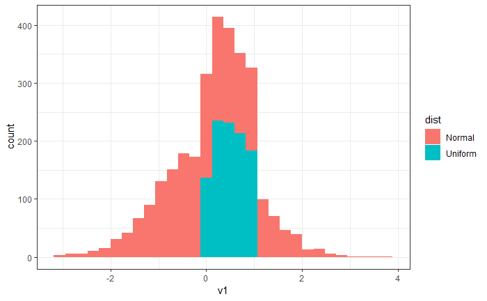

You can directly plot density curves also.

`r`r ggplot(mydata,aes(x=v1,fill=dist))+geom_density()

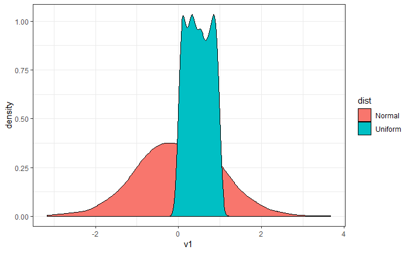

You can see that density curves are overlapping.

This can be dealt with setting transparency of fill by using aesthetic alpha which doesnt need to be mapped to data, hence it is specified outside aes.

`r`r ggplot(mydata,aes(x=v1,fill=dist))+geom_density(alpha=1/5)

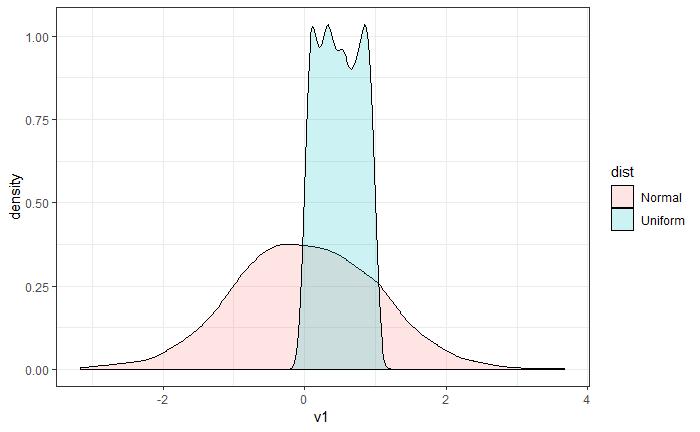

You can add histogram and density together, but there is an issue which you’ll realize soon.

`r`r ggplot(mydata,aes(x=v1,fill=dist))+geom_density(alpha=0.6)+geom_histogram(alpha=0.6)

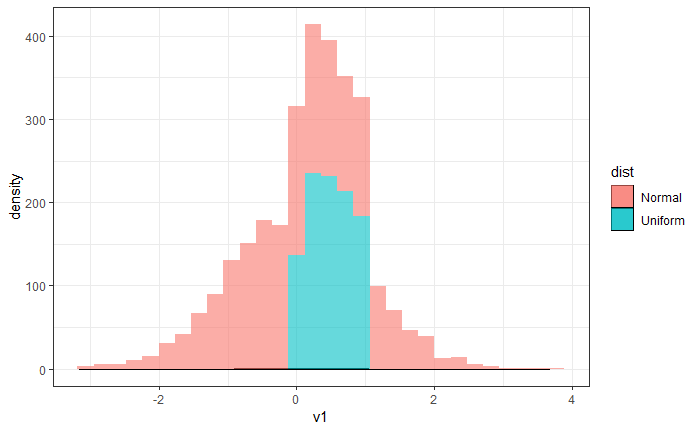

See here, density curves are no where to be seen. Believe me, they are there just that the y axis values for density are in percentages where as for histogram these are counts which obviously dominate. Hence your density curves are there but they are merely hugging x axis.

This can be taken care of by modifying y aesthetic of histograms.

`r`r ggplot(mydata,aes(x=v1,fill=dist))+geom_density(alpha=0.7)+ geom_histogram(aes(y=..density..),alpha=0.7)

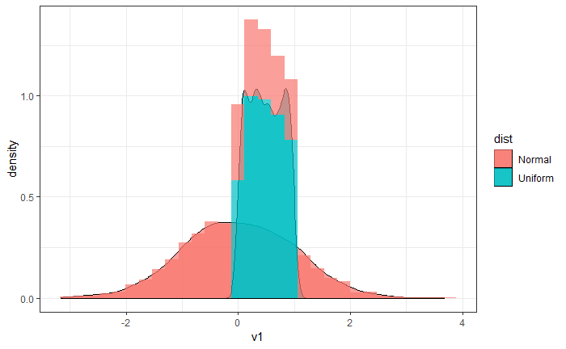

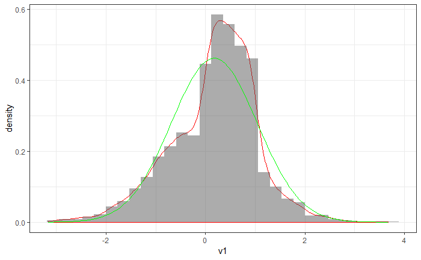

# 8. Drag and Drop Visualization

Actually, most of us prefer Tableau to do quick data analysis before creating models in R. But, now we have a tableau-like package **esquisse** in R that provides the same flexibility of drag and drop functionality to create graphs.

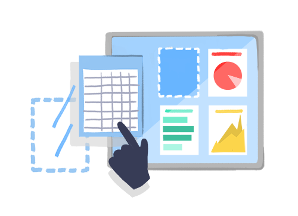

You can also export the chart to a **PNG** or **Powerpoint** format and even copy the ggplot2 code from the tool and embed it in the R code.

Next, load the library and initialize the application as shown in the below code snippet.

`r`r library(esquisse)

`r`r esquisse::esquisser(mtcars)

Once it is initialized successfully, it will pop up the app.